# MERSCOPE w/ Seurat

# 1 Introduction

The [Seurat vignette](https://satijalab.org/seurat/articles/spatial_vignette_2.html) for MERSCOPE data uses Vizgen’s previous data format for cell segmentation (hdf5 file for each FOV). The function LoadVizgen() is not currently able to load the new parquet format for cell segmentation, but this notebook demonstrates an alternate approach to load the segmentation data.”

Here we’ll walk through how to update that vignette with the new output file format (parquet).

# 2 Loading data

We are running this on a different sample/replicate than run previously in the tutorial, and it’s processed differently than previous samples.

Below are the files we will use to run the analysis.

```r
document_start_time <- Sys.time()
# getwd()
root_dir <- '../data/mouse_brain_showcase/Slice-1_Replicate-1/'

list.files(root_dir)
```

```
## [1] "cell_boundaries.parquet"     "cell_by_gene.csv"
## [3] "cell_metadata.csv"           "partitioned_transcripts.csv"
```

# 3 Processing segmentation file

The file provides 3D segmentation of cells, and as far as we know Seurat doesn’t support this 3D segmentation. Below we are going to filter to just one segmentation per cell.

For this analysis we are going to take the middle z-plane (z = 3) for cells that pass through z = 3 and the first segmentation result for any cell that doesn’t pass through the middle plane.

```r
# Loading the parquet file
segmentation <- arrow::read_parquet(paste0(root_dir, 'cell_boundaries.parquet'))

# Getting all cell ids
cell_ids <- unique(segmentation$EntityID)

# Getting cell ids for cells passing through z3
cell_ids_z3 <- unique(segmentation[segmentation$ZIndex == 3,]$EntityID)

# Getting the remaining cell ids
cell_ids_otherZ <- cell_ids[!(cell_ids %in% cell_ids_z3)]

# Getting z3 segmentations
z3_segmentation <- segmentation[segmentation$ZIndex == 3,]

# Getting segmentations for z0 or z6 for remaining cells
zOther_segmentation <- segmentation[segmentation$EntityID %in% cell_ids_otherZ,]

# Only taking the first segmentation for each cell
zOther_segmentation <- zOther_segmentation[!duplicated(zOther_segmentation$EntityID),]

# Combining the segmentaitons
combined_segmentation <- rbind(z3_segmentation,zOther_segmentation)

# Showing that we capture all cells with this strategy
dim(combined_segmentation)[1] == length(cell_ids)
```

```
## [1] TRUE
```

```r
# Since cell ID is unique we are going to use that to index the dataframe
combined_segmentation <- as.data.frame(combined_segmentation)
rownames(combined_segmentation) <- combined_segmentation$EntityID

# Ordering the combined_segmentation by the original order
combined_segmentation <- combined_segmentation[as.character(cell_ids),]

# dim(combined_segmentation)
# combined_segmentation
```

Next we are going to get the coordinates for the vertices of the segmentation polygons.

```r
segmentation <- st_as_sf(combined_segmentation)

# Pulling out a coordinate matrix for each segmentaiton
coordinates_ <- lapply(segmentation$Geometry, FUN = sf::st_coordinates)

# Getting a count of vertices for each segmentation
coordinates_labels <- lapply(segmentation$Geometry,
                             function(x){nrow(sf::st_coordinates(x))})

# Combining the matrices
coordinates_ <- do.call(rbind, coordinates_)

# Adding the vertices count
segmentation$rep <- do.call(c,coordinates_labels)

coordinates_ <- as.data.frame(coordinates_)

# Adding the metadata to the coordinates_ dataframe
coordinates_$cell <- rep(segmentation$EntityID, segmentation$rep)
```

# 4 Creating the Seurat object

```r
# Loading count data
counts <- as.data.frame(data.table::fread(paste0(root_dir,
                                                 './cell_by_gene.csv')))

# Creating a count matrix
rownames(counts) <- as.character(counts$cell)
counts <- counts[,-1]

# Pulling out a matrix of blank counts
blanks <- counts[,grepl('Blank', colnames(counts))]

# Removing blanks from the count matrix
counts <- counts[,!grepl('Blank', colnames(counts))]

# Loading the metadata file
md <- as.data.frame(data.table::fread(paste0(root_dir,
                                             './cell_metadata.csv')))

rownames(md) <- md$EntityID

# Transposing/rotating the counts file to fit Seurat convention
counts <- t(counts)

# Creating the seurat object
spat <- CreateSeuratObject(counts = counts,
                           meta.data = md,
                           assay = 'Vizgen')
```

## 4.1 Adding in spatial information

[This blog post](https://divingintogeneticsandgenomics.rbind.io/post/how-to-construct-a-spatial-object-in-seurat/) was helpful in figuring out how to add spatial information to an existing Seurat object.

This may not be the optimal way to load segmentation data into a Seurat object, and we’ll look later into improving the method.

```r
# Creating a centroid assay to visualize data in Seurat
# for most visualizations this is all you would need unless
# you wanted to interrogate the segmentation further

centroids <- md[,c('center_x','center_y','EntityID')]
colnames(centroids) <- c('x','y','cell')

# Updating the segmentation file to follow Seurat convention
coordinates_sub <- coordinates_[,c('X','Y','cell')]
colnames(coordinates_sub)[1:2] <- c('x','y')

# Creating the objects compatible with Seurat
coords <- CreateSegmentation(coordinates_sub)
cents <- CreateCentroids(centroids)

# Combining the spatial Seurat objects
segmentation.data <- list(
  "centroids" = cents,
  "segmentation" = coords
)

# Loading the transcript data
transcripts <- as.data.frame(data.table::fread(paste0(root_dir,"partitioned_transcripts.csv")))

transcripts_sub <- transcripts[,c('global_x','global_y',
                                  'gene','cell_id')]

colnames(transcripts_sub) <- c('x','y','gene','cell')

# Turning the spatial Seurat objects into one "FOV" image
coords <- CreateFOV(
  coords = segmentation.data,
  type = c('segmentation','centroids'),
  molecules = transcripts_sub,
  assay = 'Vizgen'
)

spat[['image']] <- coords
```

# 5 Basic Processing Workflow

```r
# Normalizing the data
spat <- SCTransform(spat, assay = 'Vizgen',
                    clip.range = c(-10,10))
# Finding principal components of the data
spat <- RunPCA(spat, npcs = 30, features = rownames(spat))

# Generating UMAP coordinates for cells
spat <- RunUMAP(spat, dims = 1:30)
# Finding similar cells and clustering them together
spat <- FindNeighbors(spat, reduction = 'pca', dims = 1:30)
spat <- FindClusters(spat, resolution = 0.3)
```

```
## Modularity Optimizer version 1.3.0 by Ludo Waltman and Nees Jan van Eck
##
## Number of nodes: 78273
## Number of edges: 2864281
##
## Running Louvain algorithm...
## Maximum modularity in 10 random starts: 0.9640
## Number of communities: 24
## Elapsed time: 19 seconds
```

# 6 Visualizaitons

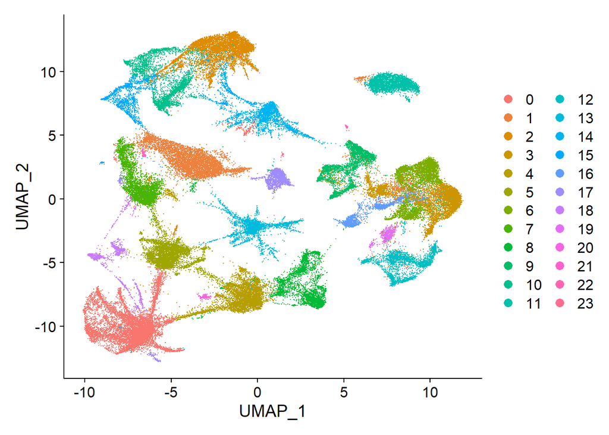

```r
# Viewing the data with UMAP
DimPlot(spat, reduction = 'umap')
```

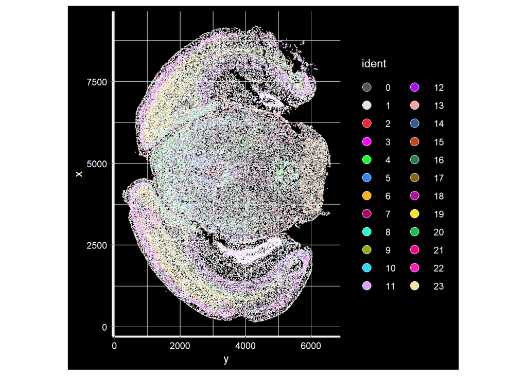

```r
# Viewing cell clusters based on spatial location
ImageDimPlot(spat, fov = 'image', cols = 'polychrome', axes = TRUE)
```

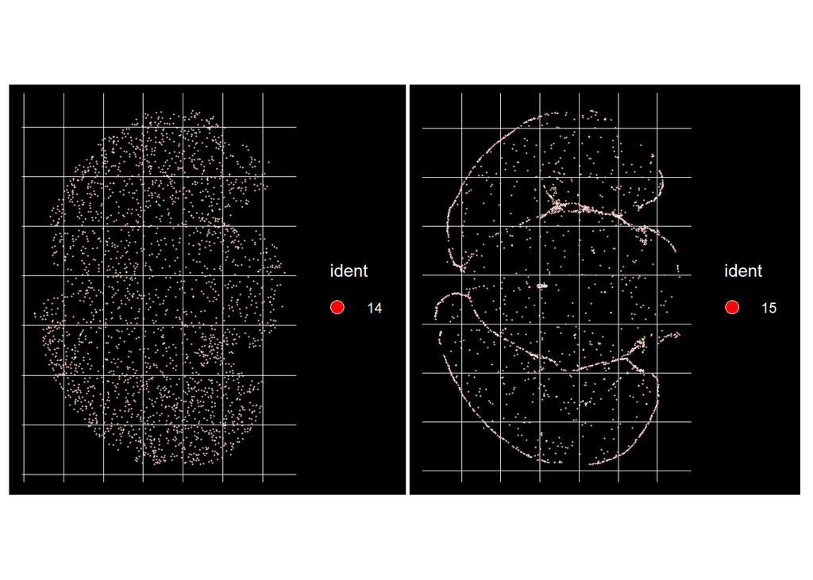

```r
# Viewing where clusters 14 & 15 locate spatially
p1 <- ImageDimPlot(spat, fov = "image", cols = "red", cells = WhichCells(spat, idents = 14))
p2 <- ImageDimPlot(spat, fov = "image", cols = "red", cells = WhichCells(spat, idents = 15))
p1 + p2
```

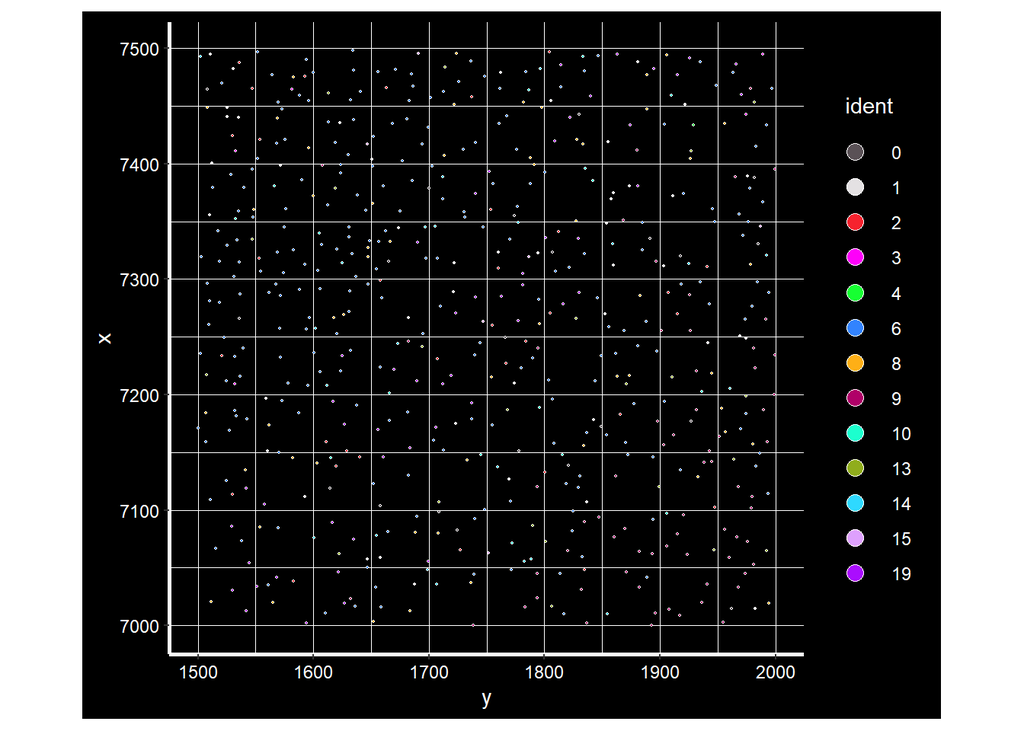

```r
# had to increase the global memory for cropping
options(future.globals.maxSize = 8000*1024^2)

# cropping the image to a subsection
cropped.coords <- Crop(spat[['image']],
                       x = c(1500,2000),
                       y = c(7000,7500),
                       coords = 'plot')
# adding that subsection to an FOV in the Seurat object
spat[['subset']] <- cropped.coords
# Plotting the cell centroids in the subset FOV
p1 <- ImageDimPlot(spat, fov = 'subset', axes = TRUE, size = 0.7,
             border.color = 'white', cols = 'polychrome',
             coord.fixed = TRUE)
p1
```

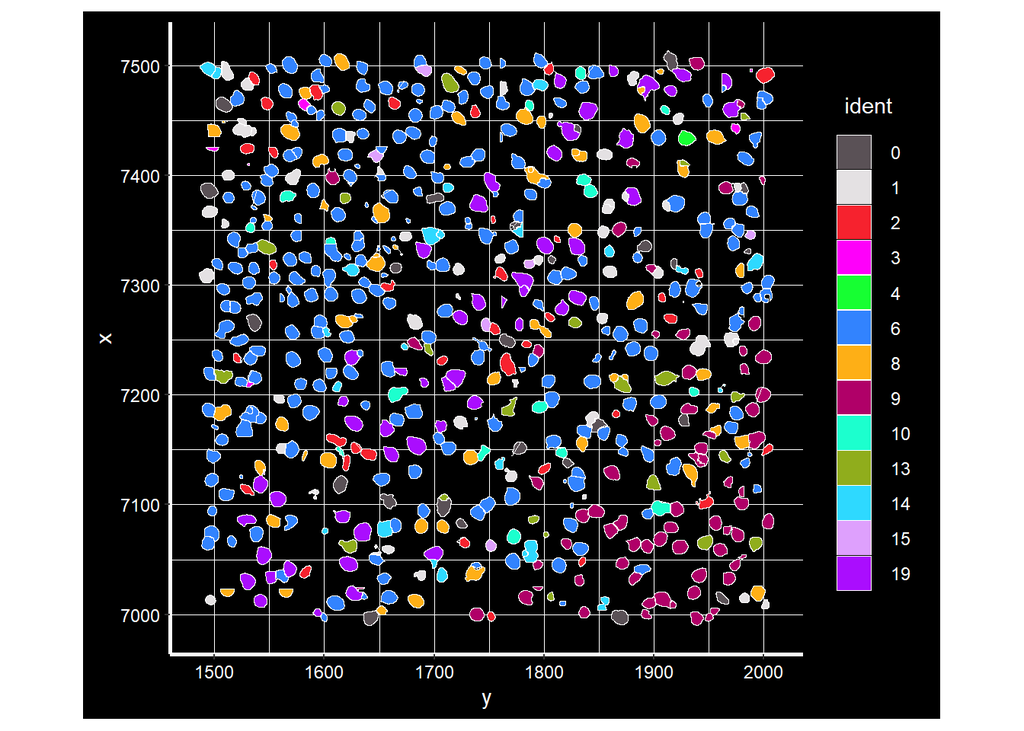

```r
# Plotting the cell segmentation in the subset FOV
p2 <- ImageDimPlot(spat, fov = 'subset', axes = TRUE, border.size = .1,
             border.color = 'white', cols = 'polychrome',
             coord.fixed = TRUE, boundaries = 'segmentation')
p2
```

Currently, we are able to run the Simplify command but unable to plot the resulting segmentation do to missing values for some segmentations.

```r
# spat[["subset"]][["simplified.segmentations"]] <- Simplify(coords = spat[["subset"]][["segmentation"]], tol = 5)
#
#
#
# x <- spat[['subset']][['simplified.segmentations']]@polygons
# for (i in x){
#   plot(i)
#   break
# }
#
# p3 <- ImageDimPlot(spat, fov = 'subset', axes = TRUE, border.size = .1,
#              border.color = 'white', cols = 'polychrome',
#              coord.fixed = TRUE, boundaries = 'simplified.segmentation')
# p3
```

Showing the cell centroid and segmentation side-by-side.

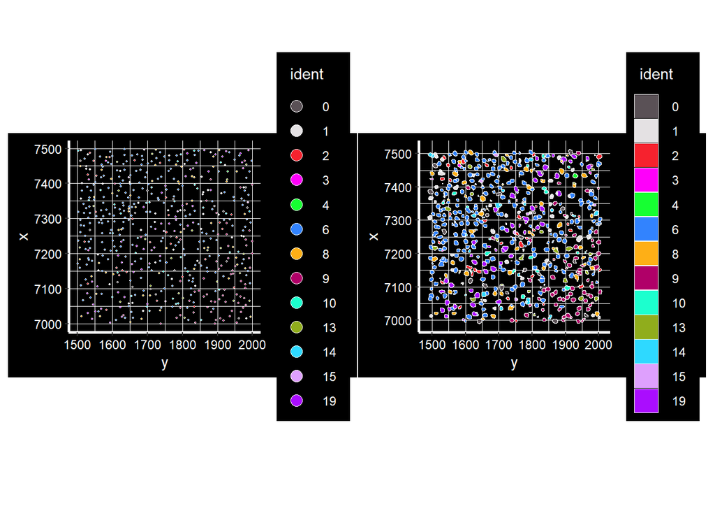

```r
p1 + p2
```

Plotting transcripts (molecules) along with the segmentation in the subset FOV.

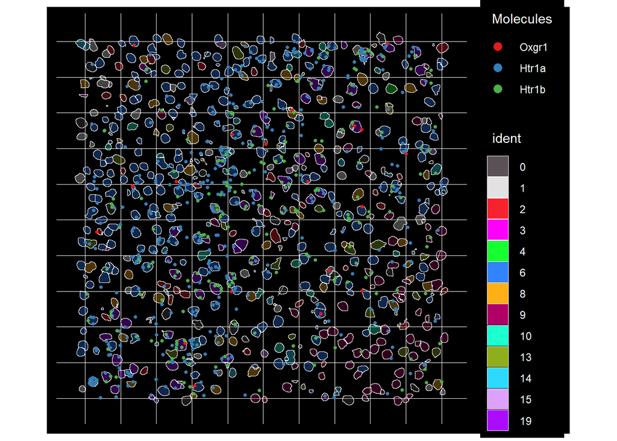

```r
# Cells colored by cluster
ImageDimPlot(spat, molecules = c("Oxgr1", "Htr1a", "Htr1b"),
             nmols = 1e4, coord.fixed = T, fov = 'subset',
             border.color = 'white', border.size = .1,
             boundaries = 'segmentation',alpha = .3,mols.size = 1,
             cols = 'polychrome')
```

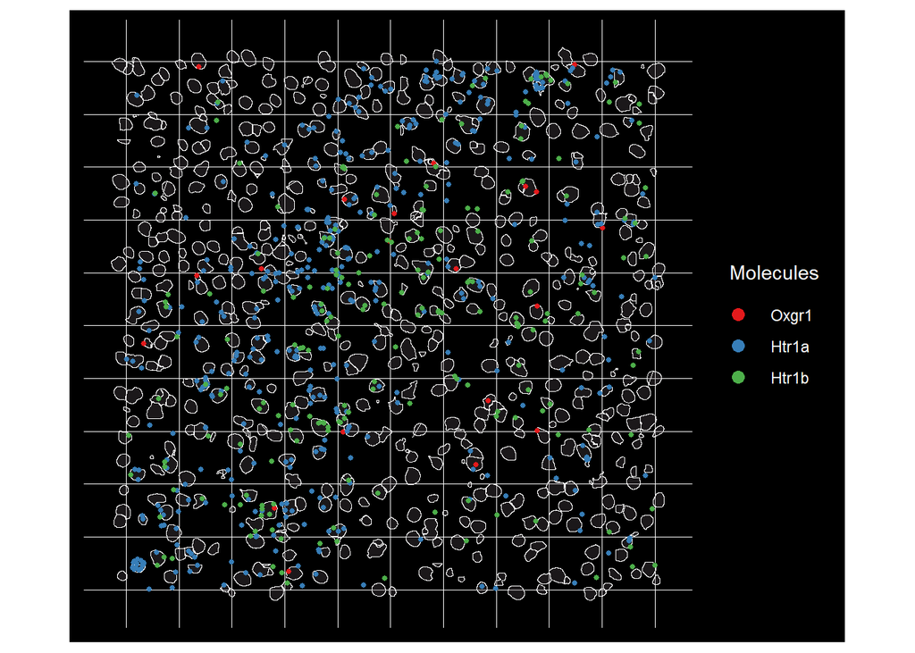

```r
# Cells not colored
ImageDimPlot(spat, molecules = c("Oxgr1", "Htr1a", "Htr1b"),
             nmols = 1e4, coord.fixed = T, fov = 'subset',
             border.color = 'white', border.size = .1,
             group.by = 'orig.ident',
             boundaries = 'segmentation',alpha = .3,mols.size = 1,
             cols = 'polychrome')
```

# 7 Session Information

Printing how long the process took

```r
end_time <- Sys.time()

end_time - document_start_time
```

```
## Time difference of 11.85605 mins
```

```r
# saveRDS(spat, '../data/mouse_brain_showcase/seurat_object.Rds')
```

```r
# spat <- readRDS('../data/mouse_brain_showcase/seurat_object.Rds')
```